# San Francisco to the Bay

Determining if San Francisco residents value transit-rich neighborhoods compared to others

Oliver Atwood + Dave Drennan + Trevor Kapuvari

2023-09-22

# 1 Motivation

Transit-oriented development (TOD) seeks to connect residents with easy and convenient transit throughout a city and/or region. As a city with one of the highest population densities in the United States, San Francisco provides the right conditions for TOD to send residents to jobs and activities across the Bay Area. However, residents ultimately determine how much they value TOD based on where they live and the amount they pay to live there.

Through this study, we examine four indicators of TOD - population density, median household income, total population, and median rent - to determine if San Franciscans value proximity to BART stops. We also take a wider view by incorporating the full BART network to contextualize San Francisco within the Bay Area.

# 2 Setup

```r
#Bundling data setup without outputs to limit appearance of technical code chunks in policy brief

#install.packages("devtools")
#devtools::install_github("kstagaman/autoNumCaptions")

# Load Libraries
library(tidyverse)
library(tidycensus)
library(sf)
library(kableExtra)
library(RSocrata)
library(dplyr)
library(stringr)
library(units)
library(gridExtra)
library(autoNumCaptions)

# we don't want scientific notation
options(scipen=999)

# set default class to return the spatial data as sf objects by default
options(tigris_class = "sf")

# load custom functions from the book
source("https://raw.githubusercontent.com/urbanSpatial/Public-Policy-Analytics-Landing/master/functions.r")

palette5 <- c("#f0f9e8","#bae4bc","#7bccc4","#43a2ca","#0868ac")

census_api_key("e13d5be5cb48d927009e0dca0af99d21918d514f", overwrite = TRUE)

#Wrangling Census data
#2009 ACS data for Bay Area

tracts09_bay <-
  get_acs(geography = "tract",
          variables = c("B25026_001E",
                        "B19013_001E",
                        "B25058_001E"),
          year=2009, state=06, county=c("001", "013", "041", "075", "081", "085", "095"),
          geometry=TRUE, output="wide") %>%
  st_transform('EPSG:2227') %>%
  rename(TotalPop = B25026_001E,
         MedHHInc = B19013_001E,
         MedRent = B25058_001E) %>%
  mutate(area = st_area(geometry)) %>%
  dplyr::select(-NAME, -starts_with("B")) %>%
  mutate(year = "2009",
         density = drop_units((TotalPop / (area * 0.00000003587 ))))

#2009 ACS data for San Francisco only

tracts09_sf <-
  get_acs(geography = "tract",
          variables = c("B25026_001E",
                        "B19013_001E",
                        "B25058_001E"),
          year=2009, state=06, county="075",
          geometry=TRUE, output="wide") %>%
  st_transform('EPSG:2227') %>%
  rename(TotalPop = B25026_001E,
         MedHHInc = B19013_001E,
         MedRent = B25058_001E) %>%
  mutate(area = st_area(geometry)) %>%
  dplyr::select(-NAME, -starts_with("B")) %>%
  mutate(year = "2009",
         density = drop_units((TotalPop / (area * 0.00000003587 ))))

#2017 ACS data for Bay Area

tracts17_bay <-
  get_acs(geography = "tract",
          variables = c("B25026_001E",
                        "B19013_001E",
                        "B25058_001E"),
          year=2017, state=06, county=c("001", "013", "041", "075", "081", "085", "095"),
          geometry=TRUE, output="wide") %>%
  st_transform('EPSG:2227') %>%
  rename(TotalPop = B25026_001E,
         MedHHInc = B19013_001E,
         MedRent = B25058_001E) %>%
  mutate(area = st_area(geometry)) %>%
  dplyr::select(-NAME, -starts_with("B")) %>%
  mutate(year = "2017",
         density = drop_units((TotalPop / (area * 0.00000003587 ))))

#2017 ACS data for San Francisco only

tracts17_sf <-
  get_acs(geography = "tract",
          variables = c("B25026_001E",
                        "B19013_001E",
                        "B25058_001E"),
          year=2017, state=06, county="075",
          geometry=TRUE, output="wide") %>%
  st_transform('EPSG:2227') %>%
  rename(TotalPop = B25026_001E,
         MedHHInc = B19013_001E,
         MedRent = B25058_001E) %>%
  mutate(area = st_area(geometry)) %>%
  dplyr::select(-NAME, -starts_with("B")) %>%
  mutate(year = "2017",
         density = drop_units((TotalPop / (area * 0.00000003587 ))))

allTracts_bay <- rbind(tracts09_bay,tracts17_bay)

allTracts_sf <- rbind(tracts09_sf,tracts17_sf)

# Wrangling Transit Open Data
BART_Stops_bay <- st_read("https://raw.githubusercontent.com/olivegardener/musa_5080_2023/main/Week_2/data/BART_System.kml")

BART_Stops_bay <- BART_Stops_bay %>%
  st_transform(2227)

sf_outline <- st_union(tracts09_sf)

# Find the points that are within the boundary
indices <- st_within(BART_Stops_bay, sf_outline, sparse = FALSE)

# Create a new sf object containing only the points within the boundary
BART_Stops_sf <- BART_Stops_bay[as.vector(indices), ]

# Cropping the extent to show relevant areas
#Buffer Bart stops for Bounding Box
Buffer4Crop <- st_union(st_buffer(BART_Stops_bay, (15*2640))) %>%
      st_sf() %>%
      mutate(Legend = "Crop Buffer")

# Get the bounding box of Buffer4Crop
bbox_Buffer4Crop <- st_bbox(Buffer4Crop)

# Crop allTracts using the bounding box of Buffer4Crop
cropped_allTracts_bay <- st_crop(allTracts_bay, bbox_Buffer4Crop)


#Crop SF only, no Farallon Islands
cropped_allTracts_sf <- st_crop(allTracts_sf, xmin = 6025077, xmax = 5957122, ymin = 2080091, ymax = 2137110)

# Creating buffers
BART_Stops_bay_Buffers <-
  rbind(
    st_buffer(BART_Stops_bay, 2640) %>%
      mutate(Legend = "Buffer") %>%
      dplyr::select(Legend),
    st_union(st_buffer(BART_Stops_bay, 2640)) %>%
      st_sf() %>%
      mutate(Legend = "Unioned Buffer"))

BART_Stops_sf_Buffers <-
  rbind(
    st_buffer(BART_Stops_sf, 2640) %>%
      mutate(Legend = "Buffer") %>%
      dplyr::select(Legend),
    st_union(st_buffer(BART_Stops_sf, 2640)) %>%
      st_sf() %>%
      mutate(Legend = "Unioned Buffer"))

buffer_bay <- filter(BART_Stops_bay_Buffers, Legend =="Unioned Buffer")

buffer_sf <- filter(BART_Stops_sf_Buffers, Legend =="Unioned Buffer")

# Selecting TOD-designated Census tracts by centroids

selectCentroids_bay <-
  st_centroid(tracts09_bay)[buffer_bay,] %>%
  st_drop_geometry() %>%
  left_join(., dplyr::select(tracts09_bay, GEOID), by = "GEOID") %>%
  st_sf() %>%
  dplyr::select(TotalPop, MedRent) %>%
  mutate(Selection_Type = "Select by Centroids")

selectCentroids_sf <-
  st_centroid(tracts09_sf)[buffer_sf,] %>%
  st_drop_geometry() %>%
  left_join(., dplyr::select(tracts09_sf, GEOID), by = "GEOID") %>%
  st_sf() %>%
  dplyr::select(TotalPop, MedRent) %>%
  mutate(Selection_Type = "Select by Centroids")

# Mapping Census tracts near transit stations
ggplot() +
  geom_sf(data=selectCentroids_bay, aes(fill = TotalPop)) +
  geom_sf(data=BART_Stops_bay, show.legend = "point") +
  scale_fill_viridis_c() +
  mapTheme()
```

```r
ggplot() +
  geom_sf(data=selectCentroids_sf, aes(fill = TotalPop)) +
  geom_sf(data=BART_Stops_sf, show.legend = "point") +
  scale_fill_viridis_c() +
  mapTheme()
```

# 3 Comparing Indicators

```r
allTracts.group_bay <-
  rbind(
    st_centroid(allTracts_bay)[buffer_bay,] %>%
      st_drop_geometry() %>%
      left_join(allTracts_bay) %>%
      st_sf() %>%
      mutate(TOD = "TOD"),
    st_centroid(allTracts_bay)[buffer_bay, op = st_disjoint] %>%
      st_drop_geometry() %>%
      left_join(allTracts_bay) %>%
      st_sf() %>%
      mutate(TOD = "Non-TOD")) %>%
    mutate(MedRent.inf = ifelse(year == "2009", MedRent * 1.15, MedRent)) %>%
  mutate(MedHHInc.inf = ifelse(year == "2009", MedHHInc * 1.15, MedHHInc)) %>%
      st_join(BART_Stops_bay)

allTracts.group_sf <-
  rbind(
    st_centroid(cropped_allTracts_sf)[buffer_sf,] %>%
      st_drop_geometry() %>%
      left_join(cropped_allTracts_sf) %>%
      st_sf() %>%
      mutate(TOD = "TOD"),
    st_centroid(cropped_allTracts_sf)[buffer_sf, op = st_disjoint] %>%
      st_drop_geometry() %>%
      left_join(cropped_allTracts_sf) %>%
      st_sf() %>%
      mutate(TOD = "Non-TOD")) %>%
    mutate(MedRent.inf = ifelse(year == "2009", MedRent * 1.15, MedRent)) %>%
  mutate(MedHHInc.inf = ifelse(year == "2009", MedHHInc * 1.15, MedHHInc)) %>%
      st_join(BART_Stops_sf)
```

## 3.1 Mapping Indicators in 2009 and 2017

### 3.1.1 TOD vs. Non TOD Areas

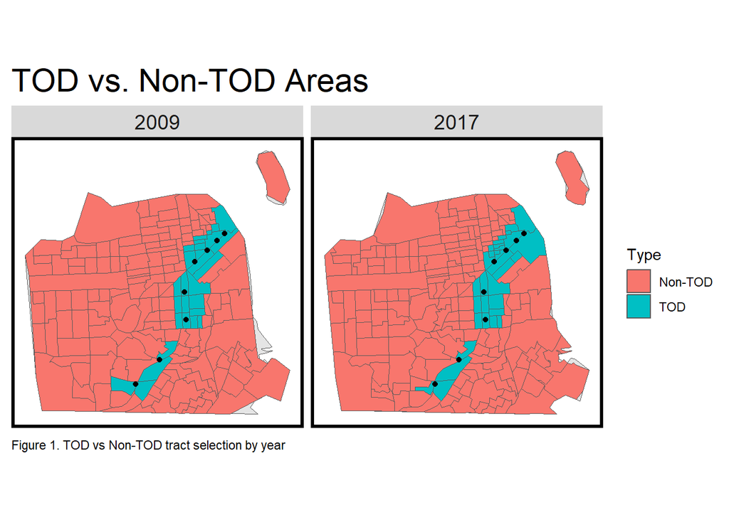

```r
ggplot(allTracts.group_sf)+
    geom_sf(data = st_union(cropped_allTracts_sf))+
    geom_sf(aes(fill = TOD)) +
    geom_sf(data = BART_Stops_sf, col = "black")+
    #geom_sf(data = buffer_sf, lwd = 1, col = "darkgoldenrod1",  fill = "NA") +
    labs(title = "TOD vs. Non-TOD Areas",
         fill = "Type") +
    facet_wrap(~year)+
    mapTheme() +
    theme(plot.title = element_text(size=22))+
    gg_figure_caption(
      caption = "TOD vs Non-TOD tract selection by year"
    )
```

TOD areas were chosen by determining what Census tracts are within half a mile of a BART stop. While the BART system is not the only public transit option within the city, the BART network provides access to major commercial areas in San Francisco as well as jobs and other activities throughout the Bay Area.

### 3.1.2 Population Density per Square Mile

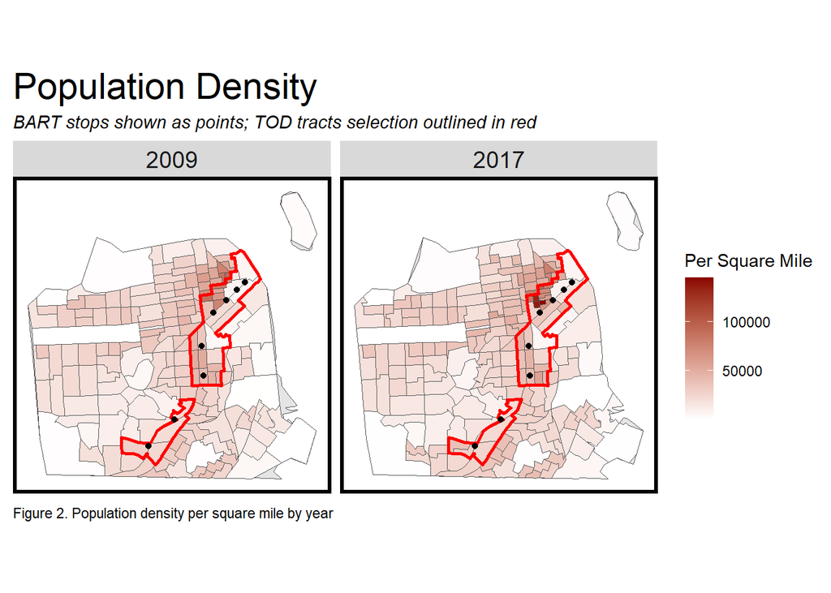

```r
ggplot(allTracts.group_sf)+
    geom_sf(data = st_union(cropped_allTracts_sf))+
    geom_sf(aes(fill = density)) +
    geom_sf(data = st_union(selectCentroids_sf), lwd = 1, col = "red",  fill = "NA") +
    geom_sf(data = BART_Stops_sf, col = "black")+
    #geom_sf(data = buffer_sf, lwd = 1, col = "darkgoldenrod1",  fill = "NA") +
    scale_fill_gradient(low = "white",high = "red4") +
    labs(title = "Population Density",
         subtitle = "BART stops shown as points; TOD tracts selection outlined in red",
         fill = "Per Square Mile") +
    facet_wrap(~year)+
    mapTheme() +
    theme(plot.title = element_text(size=22))+
    gg_figure_caption(
      caption = "Population density per square mile by year"
    )
```

Given that San Francisco already has a high population density per square mile compared to most other major cities in the United States, it is unsurprising that density did not change dramatically between 2009 and 2017. Tracts inside and outside the TOD show similar population densities across years, with the exception of a few smaller Census tracts within the northern part of the TOD area in downtown San Francisco. The higher population densities in TOD areas could also reflect development that has already occurred for transit-rich areas in the city.

Note: the increased density downtown may reflect Census tracts changing and becoming smaller due to US Census Bureau methodology.

### 3.1.3 Median Household Income

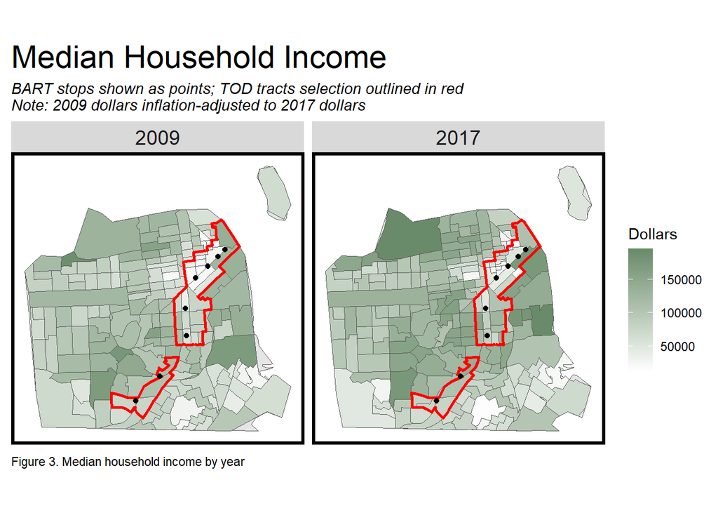

```r
ggplot(allTracts.group_sf)+
    geom_sf(data = st_union(cropped_allTracts_sf))+
    geom_sf(aes(fill = MedHHInc.inf)) +
    geom_sf(data = st_union(selectCentroids_sf), lwd = 1, col = "red",  fill = "NA") +
    geom_sf(data = BART_Stops_sf, col = "black")+
    #geom_sf(data = buffer_sf, lwd = 1, col = "darkgoldenrod1",  fill = "NA") +
    scale_fill_gradient(low = "white",high = "darkseagreen4") +
    labs(title = "Median Household Income",
         subtitle = "BART stops shown as points; TOD tracts selection outlined in red \nNote: 2009 dollars inflation-adjusted to 2017 dollars",
         fill = "Dollars") +
    facet_wrap(~year)+
    mapTheme() +
    theme(plot.title = element_text(size=22))+
    gg_figure_caption(
      caption = "Median household income by year"
    )
```

### 3.1.4 Total Population

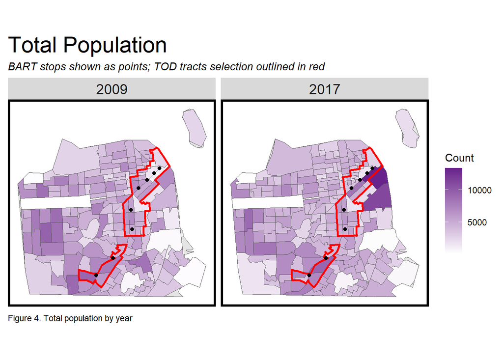

```r
ggplot(allTracts.group_sf)+
    geom_sf(data = st_union(cropped_allTracts_sf))+
    geom_sf(aes(fill = TotalPop)) +
    geom_sf(data = st_union(selectCentroids_sf), lwd = 1, col = "red",  fill = "NA") +
    geom_sf(data = BART_Stops_sf, col = "black")+
    #geom_sf(data = buffer_sf, lwd = 1, col = "darkgoldenrod1",  fill = "NA") +
    scale_fill_gradient(low = "white",high = "darkorchid4") +
    labs(title = "Total Population",
         subtitle = "BART stops shown as points; TOD tracts selection outlined in red",
         fill = "Count") +
    facet_wrap(~year)+
    mapTheme() +
    theme(plot.title = element_text(size=22))+
    gg_figure_caption(
      caption = "Total population by year"
    )
```

While population density can reflect infill development or high density development generally, total population count can help quantify the total potential customer base for transit services.

This map shows some changes between years throughout San Francisco, especially in the northeast corner of the city. Downtown areas, including TOD areas, appear to have higher population counts in 2017 compared to 2009. Taken together with figure 3, more lower income residents may place more value in close proximity to BART stops.

Note: similar to population density, these population count changes may be influenced by changes in US Census Bureau methodology - some tracts with higher population counts in the 2009 map are subdivided in the 2017 map.

### 3.1.5 Median Rent

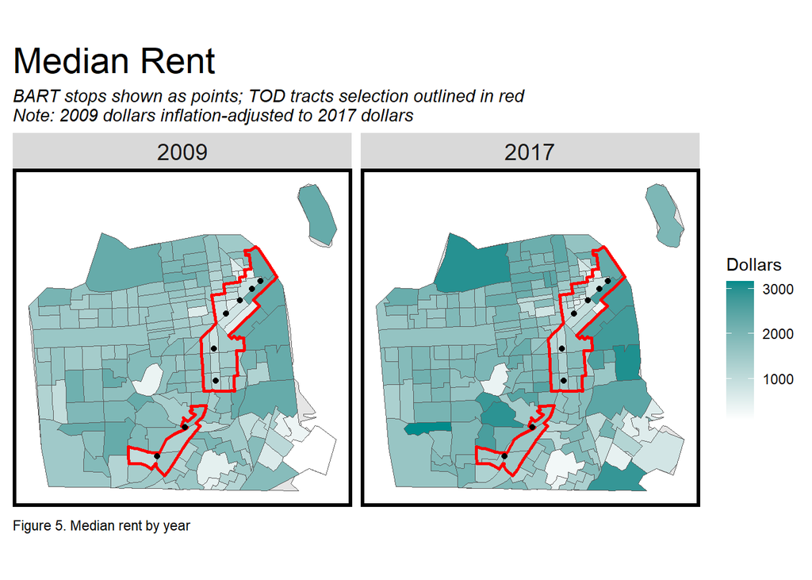

```r
ggplot(allTracts.group_sf)+
    geom_sf(data = st_union(cropped_allTracts_sf))+
    geom_sf(aes(fill = MedRent.inf)) +
    geom_sf(data = st_union(selectCentroids_sf), lwd = 1, col = "red",  fill = "NA") +
    geom_sf(data = BART_Stops_sf, col = "black")+
    #geom_sf(data = buffer_sf, lwd = 1, col = "darkgoldenrod1",  fill = "NA") +
    scale_fill_gradient(low = "white",high = "cyan4") +
    labs(title = "Median Rent",
         subtitle = "BART stops shown as points; TOD tracts selection outlined in red \nNote: 2009 dollars inflation-adjusted to 2017 dollars",
         fill = "Dollars") +
    facet_wrap(~year)+
    mapTheme() +
    theme(plot.title = element_text(size=22))+
    gg_figure_caption(
      caption = "Median rent by year"
    )
```

Similar to median household income, median rents appear to follow a similar pattern where the most growth in median rent prices occurred in areas outside of TOD areas. Following figure 3, as higher income households moved into neighborhoods outside of the TOD, they likely increased the rent costs for the area.

The tech boom of the 2010s is one potential explanation for median rents increasing along with median household income. Taken together with limited change in total population, these maps suggest that wealthier households pushed out lower income households from non-TOD areas, but that pockets of relative affordability may have remained in the denser downtown areas of the city near BART stops.

## 3.2 Plotting indicators

```r
allTracts.Summary_bay <-
  st_drop_geometry(allTracts.group_bay) %>%
  group_by(year, TOD) %>%
  summarize(Population = mean(TotalPop, na.rm = T),
            Income = mean(MedHHInc.inf, na.rm = T),
            Rent = mean(MedRent.inf, na.rm = T),
            Density = mean(density, na.rm = T))

allTracts.Summary_sf <-
  st_drop_geometry(allTracts.group_sf) %>%
  group_by(year, TOD) %>%
  summarize(Population = mean(TotalPop, na.rm = T),
            Income = mean(MedHHInc.inf, na.rm = T),
            Rent = mean(MedRent.inf, na.rm = T),
            Density = mean(density, na.rm = T))
```

## 3.3 TOD Indicators

### 3.3.1 San Francisco

The following tables and graphs provide information on TOD vs. non-TOD areas for both 2009 and 2017. Data for the Bay Area covered by the BART network is provided to help contextualize San Francisco data.

```r
allTracts.Summary_sf %>%
  unite(year.TOD, year, TOD, sep = ": ", remove = T) %>%
  gather(Variable, Value, -year.TOD) %>%
  mutate(Value = round(Value, 2)) %>%
  spread(year.TOD, Value) %>%
  kable(caption = table.caption("This table compares TOD and non-TOD indicators across years for San    Francisco")) %>%
  kable_styling()
```

Table 1. This table compares TOD and non-TOD indicators across years for San Francisco

| Variable | 2009: Non-TOD | 2009: TOD | 2017: Non-TOD | 2017: TOD |
| --- | --- | --- | --- | --- |
| Density | 24439.39 | 35889.16 | 26602.44 | 46907.98 |
| Income | 89572.24 | 61441.39 | 103317.59 | 76699.74 |
| Population | 4393.12 | 4434.47 | 4275.26 | 4964.35 |
| Rent | 1532.67 | 1162.53 | 1760.87 | 1350.94 |

### 3.3.2 Bay Area

```r
allTracts.Summary_bay %>%
  unite(year.TOD, year, TOD, sep = ": ", remove = T) %>%
  gather(Variable, Value, -year.TOD) %>%
  mutate(Value = round(Value, 2)) %>%
  spread(year.TOD, Value) %>%
  kable(caption = table.caption("This table compares TOD and non-TOD indicators across years for the Bay Area")) %>%
  kable_styling()
```

Table 2. This table compares TOD and non-TOD indicators across years for the Bay Area

| Variable | 2009: Non-TOD | 2009: TOD | 2017: Non-TOD | 2017: TOD |
| --- | --- | --- | --- | --- |
| Density | 9186.31 | 20646.75 | 10070.58 | 26416.45 |
| Income | 96789.75 | 59131.81 | 104011.89 | 69486.40 |
| Population | 4861.63 | 4191.57 | 4760.30 | 4536.57 |
| Rent | 1526.56 | 1153.36 | 1794.70 | 1346.26 |

### 3.3.3 Plotting indicators across time and space

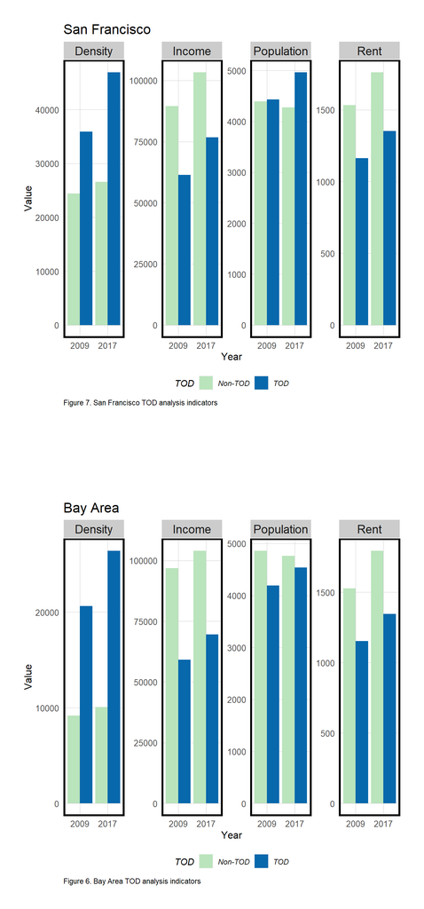

```r
bay_plot <- allTracts.Summary_bay %>%
  gather(Variable, Value, -year, -TOD) %>%
  ggplot(aes(year, Value, fill = TOD)) +
  geom_bar(stat = "identity", position = "dodge") +
  facet_wrap(~Variable, scales = "free", ncol=4) +
  scale_fill_manual(values = c("#bae4bc", "#0868ac")) +
  labs(title = "Bay Area") +
  plotTheme() + theme(legend.position="bottom", plot.margin = unit(c(2,1,1,1),"cm"))+
  xlab("Year")+
  gg_figure_caption(
      caption = "Bay Area TOD analysis indicators"
  )

sf_plot <- allTracts.Summary_sf %>%
  gather(Variable, Value, -year, -TOD) %>%
  ggplot(aes(year, Value, fill = TOD)) +
  geom_bar(stat = "identity", position = "dodge") +
  facet_wrap(~Variable, scales = "free", ncol=4) +
  scale_fill_manual(values = c("#bae4bc", "#0868ac")) +
  labs(title = "San Francisco") +
  plotTheme() + theme(legend.position="bottom", plot.margin =unit(c(1,1,2,1),"cm"))+
  xlab("Year")+
  gg_figure_caption(
      caption = "San Francisco TOD analysis indicators"
  )

grid.arrange(sf_plot, bay_plot)
```

San Francisco and the Bay Area appear to have similar experiences with TOD vs. non-TOD areas, with the exception of total population. While the scale for density is doubled in San Francisco, both the city and the Bay Area have higher population densities in TOD areas vs. non-TOD areas for 2009 and 2017. San Francisco and the region also have lower household incomes and median rents in TOD areas vs. non-TOD areas for both years. Relative growth across years appear similar for population density, median household income, and median rent.

Total population counts are higher in San Francisco TOD areas across both years. In contrast, non-TOD areas have higher total population counts in the Bay Area. However, the Bay Area did experience an increase in population counts for TOD areas between 2009 and 2017.

## 3.4 Graduated Symbol Maps

### 3.4.1 San Francisco

```r
Stops_Individual_sf <- st_buffer(BART_Stops_sf, 2640)

graduated_stops_sf <-
  st_join(Stops_Individual_sf, st_centroid(cropped_allTracts_bay)) %>%
  group_by(Name) %>%
  summarize(pop_0.5mi_sum = sum(TotalPop, na.rm = TRUE),
            rent_0.5mi_mean = round(mean(MedRent, na.rm = TRUE), digits = 0))
```

```r
#Calc centroids
tracts_centroids <- st_centroid(cropped_allTracts_sf)

# Initialize an empty vector to store distances
nearest_distances <- vector("numeric", length = nrow(tracts_centroids))

# Loop through each centroid to find the nearest point in FIRST and calculate the distance
for (i in 1:nrow(tracts_centroids)) {
  centroid <- tracts_centroids[i, ]
  nearest_index <- st_nearest_feature(centroid, graduated_stops_sf)
  nearest_point <- graduated_stops_sf[nearest_index, ]
  distance <- st_distance(centroid, nearest_point)

  # Store the distance
  nearest_distances[i] <- as.numeric(distance/5280)
}

# Add the distances to the DATABIZNESS dataframe
cropped_allTracts_sf$Distance_to_BART <- nearest_distances
```

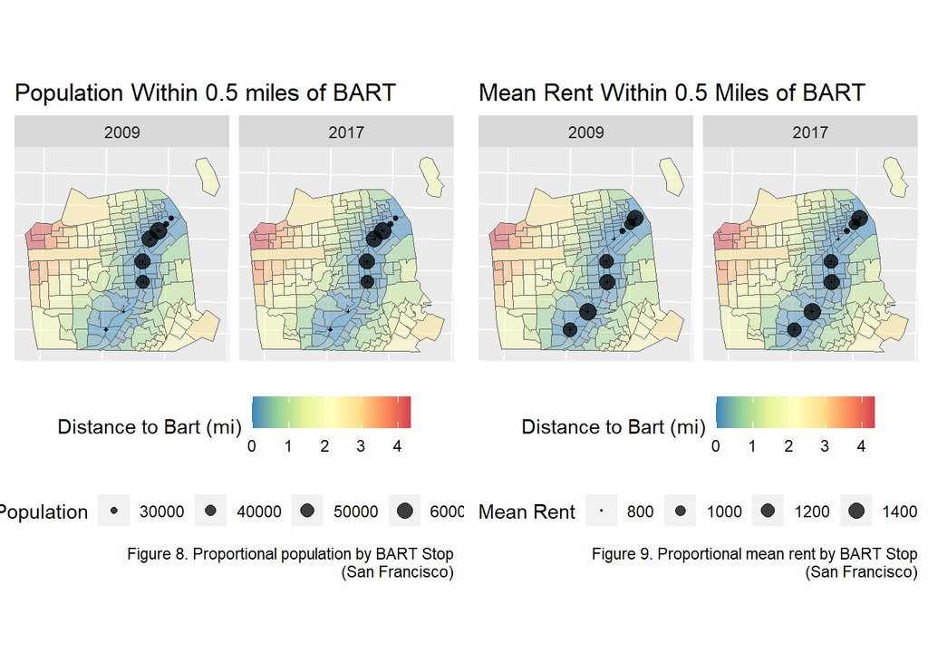

```r
# Define a common theme to remove axis text and ticks
common_theme <- theme(
  axis.text = element_blank(),
  axis.ticks = element_blank(),
  axis.title = element_blank(),
  legend.position = "bottom",
  legend.box = "vertical" # Move legend to bottom
)

# Create the first plot
stops_pop_sf <- ggplot() +
  geom_sf(data = cropped_allTracts_sf,
          aes(fill = Distance_to_BART),  # Fill color based on Dist2Bart
          color = NA,
          alpha = 0.5) +
  geom_sf(data = cropped_allTracts_sf, fill = NA, alpha = 0.5) +
  geom_sf(data = st_centroid(graduated_stops_sf),
          aes(size = pop_0.5mi_sum),
          color = 'black',
          alpha = 0.75) +
  geom_sf(data = st_centroid(graduated_stops_sf),
          aes(),
          color = 'black',
          shape = 3,
          size = 0.5) +
  scale_size_continuous(range = c(0.1, 4)) +
  scale_fill_distiller(palette = "Spectral") +
  facet_wrap(~year)+
  common_theme +
  labs(title = "Population Within 0.5 miles of BART",  # Add title
       size = "Population", # Legend title
       fill = "Distance to Bart (mi)") +   # legend title
  gg_figure_caption(
      caption = "Proportional population by BART Stop (San Francisco)",
      caption.width = 50
  )

# Create the second plot
stops_rent_sf <- ggplot() +
  geom_sf(data = cropped_allTracts_sf,
          aes(fill = Distance_to_BART),  # Fill color based on Dist2Bart
          color = NA,
          alpha = 0.5) +
  geom_sf(data = cropped_allTracts_sf, fill = NA, alpha = 0.5) +
  geom_sf(data = st_centroid(graduated_stops_sf),
          aes(size = rent_0.5mi_mean),
          color = 'black',
          alpha = 0.75) +
  geom_sf(data = st_centroid(graduated_stops_sf),
          aes(),
          color = 'black',
          shape = 3,
          size = 0.5) +
  scale_size_continuous(range = c(0.1, 4)) +
  scale_fill_distiller(palette = "Spectral") +
  facet_wrap(~year)+
  common_theme +
  labs(title = "Mean Rent Within 0.5 Miles of BART",  # Add title
       size = "Mean Rent",  # Legend title
       fill = "Distance to Bart (mi)") +  # Legend title
  gg_figure_caption(
      caption = "Proportional mean rent by BART Stop (San Francisco)",
      caption.width = 50
  )

# Arrange the plots side by side
grid.arrange(stops_pop_sf, stops_rent_sf, ncol = 2)
```

BART stops with more people nearby generally draw from areas with lower average rents. However, this relationship does not hold true for stops just south of downtown. The maps for each indicator show minimal change from 2009 to 2017.

### 3.4.2 Bay Area

```r
Stops_Individual_bay <- st_buffer(BART_Stops_bay, 2640)

graduated_stops_bay <-
  st_join(Stops_Individual_bay, st_centroid(cropped_allTracts_bay)) %>%
  group_by(Name) %>%
  summarize(pop_0.5mi_sum = sum(TotalPop, na.rm = TRUE),
            rent_0.5mi_mean = round(mean(MedRent, na.rm = TRUE), digits = 0))
```

```r
#Calc centroids
tracts_centroids <- st_centroid(cropped_allTracts_bay)

# Initialize an empty vector to store distances
nearest_distances <- vector("numeric", length = nrow(tracts_centroids))

# Loop through each centroid to find the nearest point in FIRST and calculate the distance
for (i in 1:nrow(tracts_centroids)) {
  centroid <- tracts_centroids[i, ]
  nearest_index <- st_nearest_feature(centroid, graduated_stops_bay)
  nearest_point <- graduated_stops_bay[nearest_index, ]
  distance <- st_distance(centroid, nearest_point)

  # Store the distance
  nearest_distances[i] <- as.numeric(distance/5280)
}

# Add the distances to the DATABIZNESS dataframe
cropped_allTracts_bay$Distance_to_BART <- nearest_distances
```

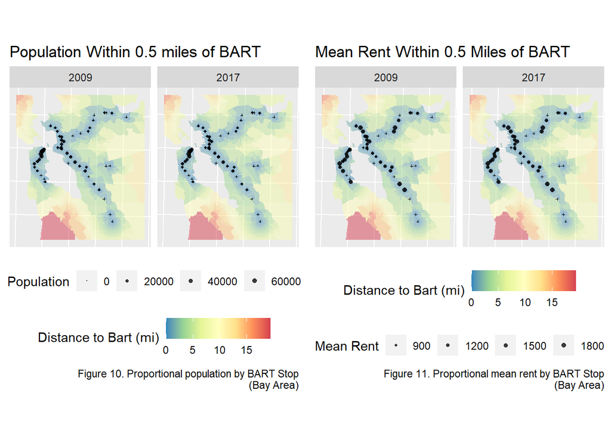

```r
# Define a common theme to remove axis text and ticks
common_theme <- theme(
  axis.text = element_blank(),
  axis.ticks = element_blank(),
  axis.title = element_blank(),
  legend.position = "bottom",
  legend.box = "vertical" # Move legend to bottom
)

# Create the first plot
stops_pop_bay <- ggplot() +
  geom_sf(data = cropped_allTracts_bay,
          aes(fill = Distance_to_BART),  # Fill color based on Dist2Bart
          color = NA,
          alpha = 0.5) +
  geom_sf(data = st_centroid(graduated_stops_bay),
          aes(size = pop_0.5mi_sum),
          color = 'black',
          alpha = 0.75) +
  geom_sf(data = st_centroid(graduated_stops_bay),
          aes(),
          color = 'black',
          shape = 3,
          size = 0.5) +
  scale_size_continuous(range = c(0.1, 1.5)) +
  scale_fill_distiller(palette = "Spectral") +
  facet_wrap(~year)+
  common_theme +
  labs(title = "Population Within 0.5 miles of BART",  # Add title
       size = "Population",
       fill = "Distance to Bart (mi)")+   # legend title
  gg_figure_caption(
      caption = "Proportional population by BART Stop (Bay Area)",
      caption.width = 50
  )

# Create the second plot
stops_rent_bay <- ggplot() +
  geom_sf(data = cropped_allTracts_bay,
          aes(fill = Distance_to_BART),  # Fill color based on Dist2Bart
          color = NA,
          alpha = 0.5) +
  geom_sf(data = st_centroid(graduated_stops_bay),
          aes(size = rent_0.5mi_mean),
          color = 'black',
          alpha = 0.75) +
  geom_sf(data = st_centroid(graduated_stops_bay),
          aes(),
          color = 'black',
          shape = 3,
          size = 0.5) +
  scale_size_continuous(range = c(0.1, 1.5)) +
  scale_fill_distiller(palette = "Spectral") +
  facet_wrap(~year)+
  common_theme +
  labs(title = "Mean Rent Within 0.5 Miles of BART",  # Add title
       size = "Mean Rent",
       fill = "Distance to Bart (mi)") +  # Legend title
  gg_figure_caption(
      caption = "Proportional mean rent by BART Stop (Bay Area)",
      caption.width = 50
  )

# Arrange the plots side by side
grid.arrange(stops_pop_bay, stops_rent_bay, ncol = 2)
```

The relationship between population and average rent described for San Francisco does not consistently appear in the Bay Area. High populations near stops are clustered around San Francisco especially, but BART stops have variability in the nearby average rents across the Bay Area. The maps for each indicator show minimal change from 2009 to 2017.

## 3.5 Multiple Ring Buffer Analysis

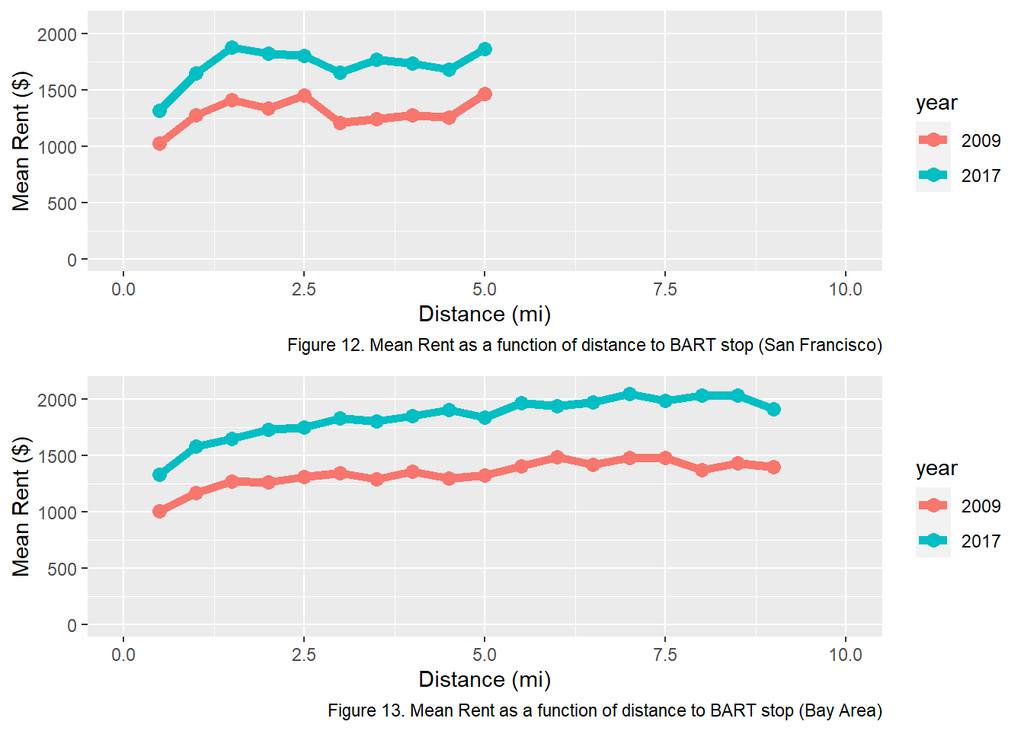

```r
BART_MRB_sf <- multipleRingBuffer(st_union(BART_Stops_sf), 47520, 2640)

allTracts.rings_sf <-
  st_join(st_centroid(dplyr::select(allTracts_sf, GEOID, year)),
          BART_MRB_sf) %>%
  st_drop_geometry() %>%
  left_join(dplyr::select(allTracts_sf, GEOID, MedRent, year),
            by=c("GEOID"="GEOID", "year"="year")) %>%
  st_sf() %>%
  mutate(distance = distance / 5280) #convert to miles

allTracts.rings.summary_sf <- st_drop_geometry(allTracts.rings_sf) %>%
    group_by(distance, year) %>%
    summarize(Mean_Rent = mean(MedRent, na.rm=T))

sf_lines <- ggplot(allTracts.rings.summary_sf,
       aes(distance, Mean_Rent, colour=year)) +
      geom_point(size=3) +
  geom_line(size=2)+
  scale_x_continuous(limits = c(0, 10))+
  scale_y_continuous(limits = c(0, 2100))+
  xlab("Distance (mi)")+
  ylab("Mean Rent ($)")+
  gg_figure_caption(
      caption = "Mean Rent as a function of distance to BART stop (San Francisco)",
  )

BART_MRB_bay <- multipleRingBuffer(st_union(BART_Stops_bay), 47520, 2640)

allTracts.rings_bay <-
  st_join(st_centroid(dplyr::select(allTracts_bay, GEOID, year)),
          BART_MRB_bay) %>%
  st_drop_geometry() %>%
  left_join(dplyr::select(allTracts_bay, GEOID, MedRent, year),
            by=c("GEOID"="GEOID", "year"="year")) %>%
  st_sf() %>%
  mutate(distance = distance / 5280) #convert to miles

allTracts.rings.summary_bay <- st_drop_geometry(allTracts.rings_bay) %>%
    group_by(distance, year) %>%
    summarize(Mean_Rent = mean(MedRent, na.rm=T))

bay_lines <- ggplot(allTracts.rings.summary_bay,
       aes(distance, Mean_Rent, colour=year)) +
      geom_point(size=3) +
  geom_line(size=2)+
  scale_x_continuous(limits = c(0, 10))+
  scale_y_continuous(limits = c(0, 2100))+
  xlab("Distance (mi)")+
  ylab("Mean Rent ($)")+
  gg_figure_caption(
      caption = "Mean Rent as a function of distance to BART stop (Bay Area)",
  )



grid.arrange(sf_lines, bay_lines)
```

In San Francisco and throughout the Bay Area, average rents generally increase the farther away an area is from a BART Stop in both 2009 and 2017. However, there is more variability in this relationship for San Francisco.

# 4 Conclusion

San Francisco residents appear to have a nuanced relationship with TOD and access to the BART network. The data suggests that wealthier renter households in the city may value other amenities more than they do proximity to a BART stop - incomes and average rents are higher in non-TOD areas compared to TOD areas. This relationship is also true across the BART network for the Bay Area and not exclusive to San Francisco. However, the TOD areas in San Francisco already have high population densities. It is possible that access to the BART network is valued by renters in those TOD areas because the system can connect them to jobs elsewhere in the region. While San Francisco renters appear unwilling to pay a premium to live near BART stops, the indicators show that given the high density and total population in TOD areas, transit-oriented development is likely already a feature of San Francisco and can benefit lower income residents.